# about – mjfrigaard

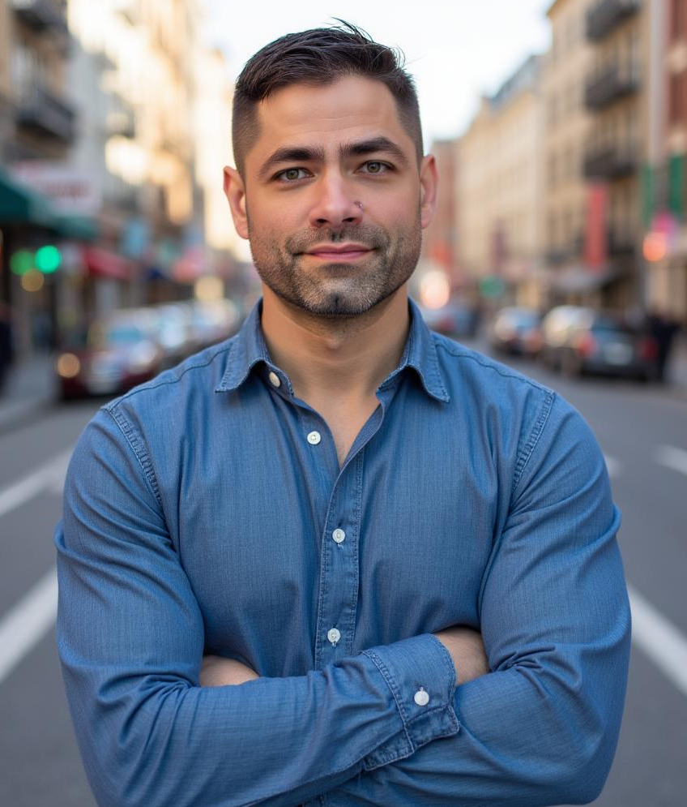

## This site

Hi! I am Martin Frigaard. Welcome to my personal blog where I write about projects I’m currently working on (or topics I’m thinking about).

## Background

For my MAS (University of California, San Francisco: 2015-2017), I investigated the prediction and diagnosis of chronic kidney disease (CKD) using electronic health records. This research examined using historical eGFRs (a lab test that measures how well kidneys filter waste) for diagnosis (it tends to overestimate the prevalence) and if a CKD diagnosis in charts indicates provider awareness (it usually does). Before that, I studied the association between hypertension and obesity in adolescents for my thesis as part of a Masters in Kinesiology degree at California State University, Chico (2009-2011).

I’m currently a Senior Application Developer at [BioMarin Pharmaceutical, Inc](https://www.biomarin.com/). I previously worked as the Posit System Administrator on the CDC’s [Enterprise Data, Analytics, and Visualization](https://www.cdc.gov/surveillance/data-modernization/technologies/edav.html), a program within the larger [Data Modernization Initiative](https://www.cdc.gov/surveillance/data-modernization/index.html). I like to develop Shiny applications, R packages, and create training materials and workshops on data management, visualizations, and reproducible research. I have 15+ years of experience with data analysis, statistics, and research. I’m also an RStudio Education Certified Instructor [`tidyverse` specialization](https://education.rstudio.com/trainers/).

[LinkedIn](https://linkedin.com/in/mjfrigaard) [Github](https://github.com/mjfrigaard) Email

[interactive chart not shown]